# Simulaciones de dinámica molecular con GROMACS

[figure not shown]

## Preliminares

### Introducción a las simulacions de Dinámica Molecular

[figure not shown]

### Librerías para manejo del notebook

```python
# Librerías de Python
import nglview               # For visualizing 3D structures
import ipywidgets            # For organizing 3D structures in panels
from IPython.display import Image
```

### Descarga del archivo PDB

```python
## Descarga del archivo PDB
!wget https://files.rcsb.org/download/5pep.pdb &> log00a.log
!cp 5pep.pdb proteina.pdb
```

```python
## Visualización resultados
!ls -tl|head -3
view = nglview.show_structure_file ("proteina.pdb")
view.add_representation (repr_type="ball+stick", selection="HOH")
view
```

[output not shown]

```
NGLWidget()
```

### Limpieza de la Proteína

```python
## Limpieza de la Proteína
!grep -v 'HOH' proteina.pdb > proteina_limpia.pdb
```

```python
## Visualización resultados
!ls -tl|head -3
view = nglview.show_structure_file ("proteina_limpia.pdb")
view.add_representation (repr_type="ball+stick", selection="HOH")
view
```

```
total 84252
-rw-rw-r-- 1 lg lg   232794 mar 22 11:36 proteina_limpia.pdb
-rw-rw-r-- 1 lg lg   263250 mar 22 11:36 proteina.pdb
```

```
NGLWidget()
```

## Generación de la topología

```python
## Creación de una topología Gromacs (PDB2GMX)
!{ echo 1;echo 1; }|gmx pdb2gmx -f proteina_limpia.pdb -o proteina_gromacs &> log01.log
```

```python
## Visualización resultados
!ls -tl|head -5
view = nglview.show_structure_file ("proteina_gromacs.gro")
view.add_representation (repr_type="ball+stick", selection="HOH")
view
```

```
total 85636
-rw-rw-r-- 1 lg lg     8142 mar 22 11:37 log01.log
-rw-rw-r-- 1 lg lg   210794 mar 22 11:37 proteina_gromacs.gro
-rw-rw-r-- 1 lg lg  1290677 mar 22 11:37 topol.top
-rw-rw-r-- 1 lg lg    75479 mar 22 11:37 posre.itp
```

```
NGLWidget()
```

## Generación una caja de simulación y adición de solvente

```python
## Generación una caja de simulación
!gmx editconf -f conf.gro -c -d 1 -bt cubic -o proteina_caja.gro &> log02a.log
```

```python
## Visualización resultados
!ls -tl|head -5
```

```
total 85640
-rw-rw-r-- 1 lg lg     2959 mar 22 11:37 log02a.log
-rw-rw-r-- 1 lg lg     8142 mar 22 11:37 log01.log
-rw-rw-r-- 1 lg lg   210794 mar 22 11:37 proteina_gromacs.gro
-rw-rw-r-- 1 lg lg  1290677 mar 22 11:37 topol.top
```

```python
## Adicción de solvente al sistema
!gmx solvate -cp proteina_caja.gro -cs spc216.gro -o proteina_solvente.gro -p topol.top &> log02b.log
```

```python
## Visualización resultados
!ls -tl|head -5
view = nglview.show_structure_file ("proteina_solvente.gro")
view.add_representation (repr_type="cartoon", color="green")
view.add_representation (repr_type="point", selection="SOL")
view
```

```
total 89648
-rw-rw-r-- 1 lg lg     4116 mar 22 11:37 log02b.log
-rw-rw-r-- 1 lg lg  1290708 mar 22 11:37 topol.top
-rw-rw-r-- 1 lg lg  2800169 mar 22 11:37 proteina_solvente.gro
-rw-rw-r-- 1 lg lg     2959 mar 22 11:37 log02a.log
```

```
NGLWidget()
```

## Adición de iones y creación de un sistema de carga neutra

La adición de iones se realiza en dos partes: primero, debe usar la herramienta grompp para generar un archivo .tpr que se usará al agregar iones, y luego debe reemplazar algunos de las moléculas solventes agregados recientemente con los contraiones necesarios usando genion.

La herramienta de preprocesador GROMACS grompp lee archivos de coordenadas y topología para generar un archivo de entrada de nivel atómico (con una extensión .tpr). Este archivo .tpr contiene todos los parámetros necesarios para todos los átomos del sistema. Para generar un archivo .tpr de entrada de ejecución, grompp necesita un archivo de estructura (.gro), un archivo de topología (.top) y un archivo que define las instrucciones para la ejecución de la simulación (esto se guarda en un archivo .mdp). Este archivo .mdp se puede mantener vacío cuando se ioniza el sistema, ya que no se ejecutará ninguna simulación real.

```python
# Crea un archivo .mdp vacio
!touch mdrun.mdp
!gmx grompp -f parametros_iones.mdp -c proteina_solvente.gro -p topol.top -o parametros_iones.tpr &> log03a.log
```

Ahora que se ha generado el .tpr, se puede usar genion para neutralizar la carga del sistema. La carga del sistema disminuye reemplazando varias partes del sistema con aniones y cationes. Esto se hace ejecutando lo siguiente:

```python
!echo 13 |gmx genion -s parametros_iones.tpr -p topol.top -neutral -o proteina_iones.gro &> log03b.log
```

```python
## Visualización resultados
!ls -tl|head -7
view = nglview.show_structure_file ("proteina_iones.gro")
view.add_representation (repr_type="cartoon", color="green")
#view.add_representation (repr_type="point", selection="SOL", color="gray")
view.add_representation (repr_type="point", selection="NA", color="yellow")
view
```

```
total 93656
-rw-rw-r-- 1 lg lg     5787 mar 22 11:37 log03b.log
-rw-rw-r-- 1 lg lg  2796758 mar 22 11:37 proteina_iones.gro
-rw-rw-r-- 1 lg lg  1290724 mar 22 11:37 topol.top
-rw-rw-r-- 1 lg lg     2999 mar 22 11:37 log03a.log
-rw-rw-r-- 1 lg lg        0 mar 22 11:37 mdrun.mdp
-rw-rw-r-- 1 lg lg     4116 mar 22 11:37 log02b.log
```

```
NGLWidget()
```

## Minimización de energía

### Archivo de configuración de la simulación (minim.mdp)

```python
!cat simulacion_minim.mdp
```

```
; MINIMIZATION RUN (minim.mdp)
;(used as input into grompp to generate em.tpr)
;
; Parameters describing what to do, when to stop, and what to save
integrator  = steep         ; A steepest descent algorithm for energy minimization
emtol       = 1000.0        ; Stop minimization when the maximum force < 1000.0 kJ/mol/nm
emstep      = 0.01          ; Minimization step size
nsteps      = 500         ; 5000 Maximum number of (minimization) steps to perform

;ELECTROSTATIC AND VDWAALS
; Parameters describing how to find the neighbors of each atom and how to calculate the interactions
nstlist         = 1         ; Frequency to update the neighbor list and long range forces
cutoff-scheme   = Verlet    ; Buffered neighbor searching
ns_type         = grid      ; Method to determine neighbor list (simple, grid)
coulombtype     = PME       ; Treatment of long range electrostatic interactions
rcoulomb        = 1.0       ; Short-range electrostatic cut-off (nm)
rvdw            = 1.0       ; Short-range Van der Waals cut-off (nm)
pbc             = xyz       ; Periodic Boundary Conditions in all 3 dimensions
```

```python
## Preparación archivo de simulación&
!gmx grompp -f simulacion_minim.mdp -c proteina_iones.gro -p topol.top -o simulacion_minim.tpr &> log04a.log
```

```python
## Ejecución de la simulación
!gmx mdrun -v -deffnm simulacion_minim &> log04b.log
```

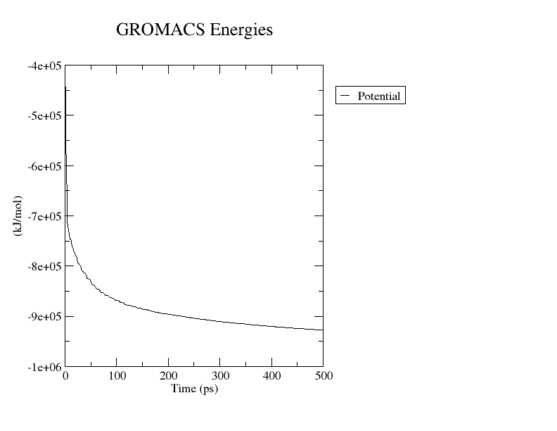

```python
## Analysis de la simulación: Energía potencial
!echo 10 | gmx energy -f simulacion_minim.edr -o energia_potencial.xvg &> log04c.log
!grace -nxy energia_potencial.xvg -hdevice PNG -hardcopy -printfile energia_potencial.png
Image(filename='energia_potencial.png', width = 400, height = 400)
```

## Equilibramiento

### Simulación de Equilibración NVT

```python
!gmx grompp -f simulacion_nvt.mdp -c simulacion_minim.gro -r simulacion_minim.gro -p topol.top -o simulacion_nvt.tpr &> log05a.log
!gmx mdrun -v -deffnm simulacion_nvt &> log05b.log
```

```
total 124580
-rw-rw-r-- 1 lg lg     3689 mar 22 11:38 log05b.log
-rw-rw-r-- 1 lg lg    28942 mar 22 11:38 simulacion_nvt.log
-rw-rw-r-- 1 lg lg     3676 mar 22 11:38 simulacion_nvt.edr
-rw-rw-r-- 1 lg lg  4288334 mar 22 11:38 simulacion_nvt.gro
ls: write error: Broken pipe
```

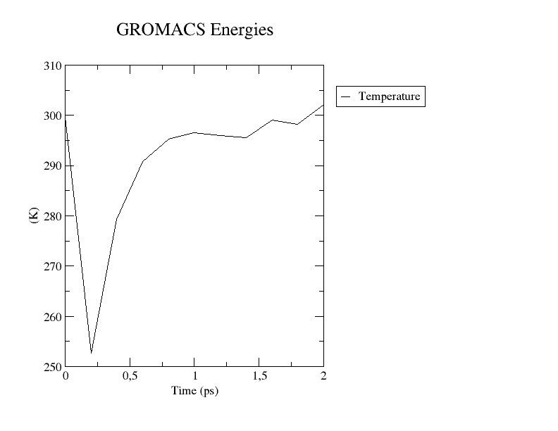

```python
## Resultados simulación NVT
!ls -lt|head -5
!echo 16 | gmx energy -f simulacion_nvt.edr -o temperatura.xvg &> log05c.log
!grace -nxy temperatura.xvg -hdevice PNG -hardcopy -printfile temperatura.png
Image(filename='temperatura.png', width = 400, height = 400)
```

### Simulación de Equilibración NPT

```python
!gmx grompp -f simulacion_npt.mdp -c simulacion_nvt.gro -r simulacion_nvt.gro -t simulacion_nvt.cpt -p topol.top -o simulacion_npt.tpr &> log05d.log
!gmx mdrun -v -deffnm simulacion_npt &> log05dd.log
```

[output not shown]

[output cut: 11 more lines]

[output not shown]

```
total 149200
-rw-rw-r-- 1 lg lg    28834 mar 22 11:39 simulacion_npt.log
-rw-rw-r-- 1 lg lg     4348 mar 22 11:39 simulacion_npt.edr
-rw-rw-r-- 1 lg lg  4288334 mar 22 11:39 simulacion_npt.gro
-rw-rw-r-- 1 lg lg 16408656 mar 22 11:39 simulacion_npt.trr
ls: write error: Broken pipe
```

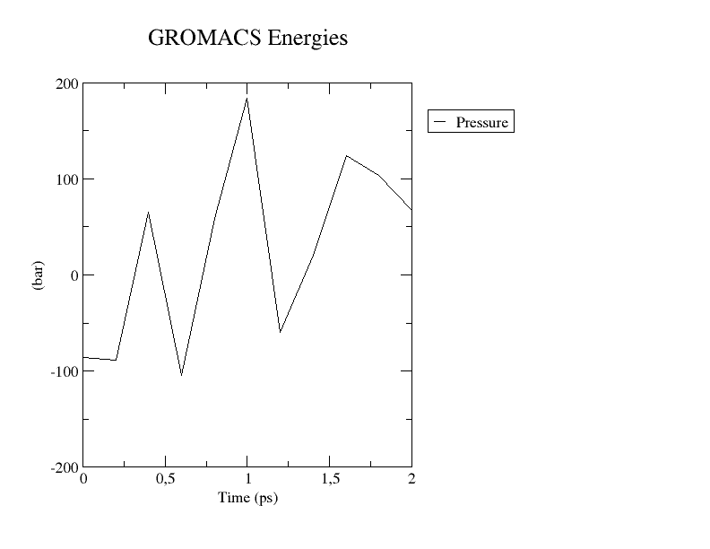

```python
## Resultados simulación NPT
!ls -lt|head -5
!echo 18 | gmx energy -f simulacion_npt.edr -o presion.xvg &> log05e.log
!grace -nxy presion.xvg -hdevice PNG -hardcopy -printfile presion.png
Image(filename='presion.png', width = 400, height = 400)
```

## Simulación de Producción

```python
!gmx grompp -f simulacion_prod.mdp -c simulacion_npt.gro -t simulacion_npt.cpt -p topol.top -o simulacion_prod.tpr &> log06a.log
!gmx mdrun -v -deffnm simulacion_prod &> log06b.log
```

## Análisis de la Simulación

### Preprocesamiento de la trajectoria

```python
!{ echo 1; echo 0; } | gmx trjconv -s simulacion_prod.tpr -f simulacion_prod.xtc -o simulacion_prod_noPBC.xtc -pbc mol -center &> log07a.log
```

### Desviación cuadrática media raíz (RMSD)

```python
!{ echo 4;echo 4; }|gmx rms -s simulacion_prod.tpr -f simulacion_prod_noPBC.xtc -o rmsd.xvg -tu ns &> log07b.log
```

```
total 162436
-rw-rw-r-- 1 lg lg     5170 mar 22 11:40 log07b.log
-rw-rw-r-- 1 lg lg      897 mar 22 11:40 rmsd.xvg
-rw-rw-r-- 1 lg lg     5865 mar 22 11:40 log07a.log
-rw-rw-r-- 1 lg lg  2494240 mar 22 11:40 simulacion_prod_noPBC.xtc
```

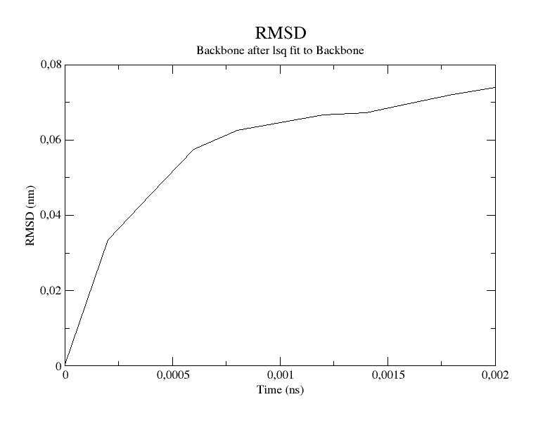

```python
## Resultados simulación Producción
!ls -lt|head -5
!grace -nxy rmsd.xvg -hdevice PNG -hardcopy -printfile rmsd.png
Image(filename='rmsd.png', width = 400, height = 400)
```